# R Code Examples

STAT 251 Section 01

2026-09-11

This page shows how to build the graphs and descriptive statistics we cover in class using R. Everything is done twice where it makes sense: once with the plotting tools built into R, and once with the **ggplot2** package.

Neither is more correct than the other. Base R is fewer keystrokes for a quick look at your data. ggplot2 takes longer to learn but gives you far more control once you know it, and is what most published figures are made with.

# The data

The examples all use a survey of college students in Georgia. Scroll the table sideways to see all 17 variables, or use the download button to open it in Excel or Google Sheets:

|  | Height | Gender | Haircut | Job | Studytime | Smokecig | Dated | HSGPA | CGPA | HomeDist | BrowseInternet | WatchTV | Exercise | ReadNewsP | Vegan | PoliticalDegree | PoliticalAff |
| --- | --- | --- | --- | --- | --- | --- | --- | --- | --- | --- | --- | --- | --- | --- | --- | --- | --- |
| 1 | 65 | 1 | 25 | 1 | 7 | 0 | 0 | 3.9 | 3.3 | 1 | 60 | 120 | 0 | 4 | 0 | 4 | 2 |
| 2 | 71 | 0 | 12 | 0 | 2 | 0 | 1 | 3.79 | 3.13 | 5 | 20 | 120 | 1 | 0 | 0 | 2 | 3 |
| 3 | 68 | 1 | 4 | 0 | 4 | 0 | 1 | 3 | 3.6 | 15 | 60 | 90 | 1 | 1 | 0 | 2 | 3 |
| 4 | 64 | 1 | 0 | 1 | 3.5 | 0 | 1 | 3.9 | 3.5 | 0.75 | 10 | 120 | 15 | 1 | 0 | 4 | 2 |
| 5 | 64 | 1 | 50 | 0 | 4.5 | 0 | 1 | 3.6 | 3.5 | 40 | 30 | 120 | 6 | 2 | 0 | 5 | 2 |
| 6 | 66 | 0 | 10 | 1 | 3 | 0 | 3 | 3.2 | 3.75 | 5 | 30 | 120 | 7 | 5 | 0 | 4 | 1 |
| 7 | 74 | 0 | 0 | 0 | 3 | 0 | 0 | 3.78 | 3.47 | 1 | 0 | 0 | 7 | 4 | 0 | 6 | 2 |
| 8 | 69 | 1 | 18 | 0 | 8 | 1 | 1 | 3.2 | 2.8 | 40 | 10 | 60 | 4 | 2 | 0 | 6 | 2 |
| 9 | 65 | 1 | 55 | 0 | 5.5 | 0 | 0 | 3.5 | 2.88 | 7 | 15 | 90 | 2.5 | 3 | 0 | 7 | 2 |
| 10 | 68 | 1 | 41 | 1 | 5.5 | 0 | 0 | 3.8 | 3.28 | 3 | 10 | 60 | 3 | 0 | 0 | 5 | 2 |

[output cut: 49 more lines]

You can also download the raw file directly: georgia_student_survey.csv (3 KB)

**Variable Description**

- Height - height measured in inches
- Gender - Gender recorded as female = 0, male = 1
- Haircut - Cost (in whole dollars) willing to spend on a haircut
- Job - If the student is employed (Yes = 1, No = 0)
- Studytime - Average time spent studying over a week (recorded in hours)
- Smokecig - If the student smokes recorded as No = 0 and Yes = 1
- Dated - Number of romantic dates in a typical week
- HSGPA - High school Grade Point Average (GPA)
- CGPA - College Grade Point Average (GPA)
- HomeDist - Distance from home to collage (in miles)
- BrowseInternet - Time spent each day browsing the web (recorded in minutes)
- WatchTV - Time spent watching TV each day (recorded in minutes)
- Exercise - Average time spent exercising over a week (recorded in hours)
- ReadNewsP - Number of days a week the student reads the newspaper
- Vegan - Whether the student is a vegan (Yes = 1, No = 0)
- PoliticalDegree - Degree of conservatism or liberalism (1 = extremely liberal, 2 = liberal, 3 = slightly liberal, 4 = moderate, 5 = slightly conservative, 6 = conservative, 7 = extremely conservative)
- PoliticalAff - The self reported political affilation of the student (1 = Democrat, 2 = Republican, 3 = Democrat)

# Getting to know a dataset

The first two things to run on any new dataset are `str()` and `summary()`.

`str()` reports the **type** R has given each variable. There are four types worth knowing about:

- **character** — a qualitative variable stored as text.
- **factor** — a qualitative variable stored as categories, often recorded with numbers like 0 and 1.
- **integer** — a quantitative *discrete* variable, i.e. whole numbers.
- **numeric** — a quantitative *continuous* variable.

```r
# structure: one line per variable, showing its type and first few values
str(gss)
```

```
## 'data.frame':    59 obs. of  17 variables:
##  $ Height         : int  65 71 68 64 64 66 74 69 65 68 ...
##  $ Gender         : int  1 0 1 1 1 0 0 1 1 1 ...
##  $ Haircut        : int  25 12 4 0 50 10 0 18 55 41 ...
##  $ Job            : int  1 0 0 1 0 1 0 0 0 1 ...
##  $ Studytime      : num  7 2 4 3.5 4.5 3 3 8 5.5 5.5 ...
##  $ Smokecig       : int  0 0 0 0 0 0 0 1 0 0 ...
##  $ Dated          : int  0 1 1 1 1 3 0 1 0 0 ...
##  $ HSGPA          : num  3.9 3.79 3 3.9 3.6 3.2 3.78 3.2 3.5 3.8 ...
##  $ CGPA           : num  3.3 3.13 3.6 3.5 3.5 3.75 3.47 2.8 2.88 3.28 ...
##  $ HomeDist       : num  1 5 15 0.75 40 5 1 40 7 3 ...
##  $ BrowseInternet : int  60 20 60 10 30 30 0 10 15 10 ...
##  $ WatchTV        : int  120 120 90 120 120 120 0 60 90 60 ...
##  $ Exercise       : num  0 1 1 15 6 7 7 4 2.5 3 ...
##  $ ReadNewsP      : int  4 0 1 1 2 5 4 2 3 0 ...
##  $ Vegan          : int  0 0 0 0 0 0 0 0 0 0 ...
##  $ PoliticalDegree: int  4 2 2 4 5 4 6 6 7 5 ...
##  $ PoliticalAff   : int  2 3 3 2 2 1 2 2 2 2 ...
```

`summary()` gives a five-number summary of every variable at once. Be careful reading it: a qualitative variable that happens to be recorded as 0/1 will get a mean and quartiles like any other number, and those are meaningless until you tell R it is a category.

```r
# five-number summary of every column
summary(gss)
```

```
##      Height          Gender          Haircut            Job
##  Min.   :60.00   Min.   :0.0000   Min.   :  0.00   Min.   :0.0000
##  1st Qu.:65.00   1st Qu.:0.0000   1st Qu.: 10.50   1st Qu.:0.0000
##  Median :68.00   Median :1.0000   Median : 20.00   Median :0.0000
##  Mean   :67.25   Mean   :0.7119   Mean   : 27.75   Mean   :0.3729
##  3rd Qu.:69.00   3rd Qu.:1.0000   3rd Qu.: 40.00   3rd Qu.:1.0000
##  Max.   :74.00   Max.   :1.0000   Max.   :150.00   Max.   :1.0000
##    Studytime         Smokecig           Dated           HSGPA
##  Min.   : 2.000   Min.   :0.00000   Min.   :0.000   Min.   :2.550
##  1st Qu.: 3.000   1st Qu.:0.00000   1st Qu.:0.000   1st Qu.:3.765
##  Median : 4.500   Median :0.00000   Median :1.000   Median :3.900
##  Mean   : 5.022   Mean   :0.05085   Mean   :0.678   Mean   :3.802
##  3rd Qu.: 6.000   3rd Qu.:0.00000   3rd Qu.:1.000   3rd Qu.:4.000
##  Max.   :15.000   Max.   :1.00000   Max.   :3.000   Max.   :4.000
##       CGPA          HomeDist    BrowseInternet      WatchTV
##  Min.   :2.500   Min.   : 0.5   Min.   :  0.00   Min.   :  0.00
##  1st Qu.:3.495   1st Qu.: 1.0   1st Qu.: 15.00   1st Qu.: 30.00
##  Median :3.750   Median : 2.5   Median : 30.00   Median : 60.00
##  Mean   :3.612   Mean   : 8.0   Mean   : 46.53   Mean   : 65.85
##  3rd Qu.:3.860   3rd Qu.: 6.5   3rd Qu.: 60.00   3rd Qu.:105.00
##  Max.   :4.000   Max.   :70.0   Max.   :180.00   Max.   :180.00
##     Exercise        ReadNewsP         Vegan        PoliticalDegree
##  Min.   : 0.000   Min.   :0.000   Min.   :0.0000   Min.   :1.000
##  1st Qu.: 3.000   1st Qu.:1.000   1st Qu.:0.0000   1st Qu.:4.000
##  Median : 4.000   Median :2.000   Median :0.0000   Median :5.000
##  Mean   : 5.949   Mean   :2.593   Mean   :0.1017   Mean   :4.593
##  3rd Qu.: 6.250   3rd Qu.:4.000   3rd Qu.:0.0000   3rd Qu.:6.000
##  Max.   :60.000   Max.   :7.000   Max.   :1.0000   Max.   :7.000
##   PoliticalAff
##  Min.   :1.000
##  1st Qu.:2.000
##  Median :2.000
##  Mean   :2.119
##  3rd Qu.:2.500
##  Max.   :3.000
```

# Describing a qualitative variable

We will use **Gender**, recorded as 0 and 1.

R has stored it as numbers, so we first have to convert it to a *factor*. That is what tells R to treat 0 and 1 as two categories rather than two values to do arithmetic with.

```r
# convert to a factor so R treats the values as categories, not numbers
gss$Gender = as.factor(gss$Gender)

# now reported as a factor with two levels
str(gss$Gender)
```

```
##  Factor w/ 2 levels "0","1": 2 1 2 2 2 1 1 2 2 2 ...
```

```r
# on a factor, summary() counts observations per level instead of averaging
summary(gss$Gender)
```

```
##  0  1
## 17 42
```

## Building a frequency table

Both a pie chart and a bar chart need the categories and their proportions, so we build a small frequency table first.

```r
# frequency = the count in each category
freq = summary(gss$Gender)

# relative frequency = each count divided by the sample size
relative.freq = round(freq/sum(freq), 2)

# repackage as a two-column table for plotting
ft = cbind.data.frame(Gender = c('Female', 'Male'), Proportion = relative.freq)
print(ft)
```

```
##   Gender Proportion
## 0 Female       0.29
## 1   Male       0.71
```

## Pie and bar charts in base R

Use `?pie` and `?barplot` to read the documentation for these and see every argument they accept.

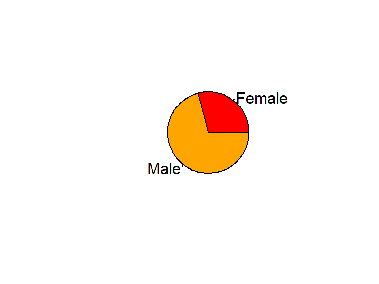

```r
pie(ft$Proportion,       # first argument: non-negative values (counts or proportions)
    labels = ft$Gender,   # category names
    col = c('red','orange'))
```

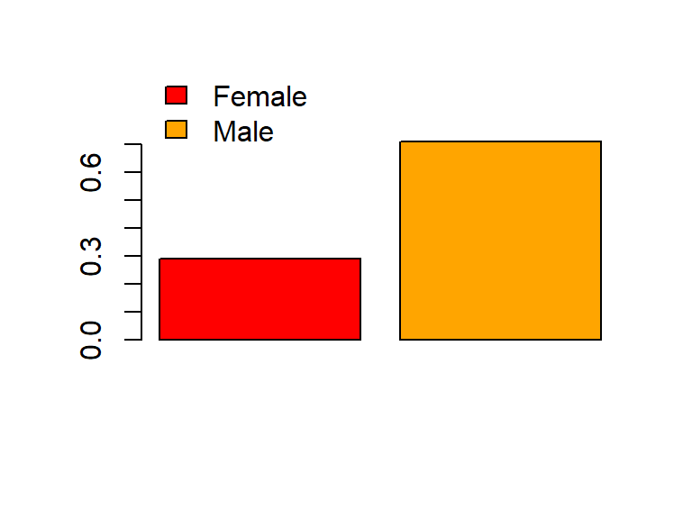

```r
barplot(height = ft$Proportion,   # first argument: the bar heights
        legend = ft$Gender,       # legend labels
        col = c('red','orange'),
        # move the legend so it does not sit on top of a bar
        args.legend = list(x = 1, y = 1, bty = "n"))
```

## The same charts in ggplot2

Every ggplot is assembled by **adding** pieces together with `+`. You start with a blank frame from `ggplot()` and add the geometry you want:

`geom_bar()`, `geom_boxplot()`, `geom_histogram()`, `geom_point()`, `geom_line()`, `geom_dotplot()`, `geom_step()`, and many more — most of which can be combined.

Every plot also needs an `aes()` argument, the *aesthetic mapping*. That is what tells ggplot which variable is x, which is y, and which controls colour or size.

ggplot2 has no pie chart. You make one by drawing a stacked bar and then bending it around a circle with `coord_polar()`:

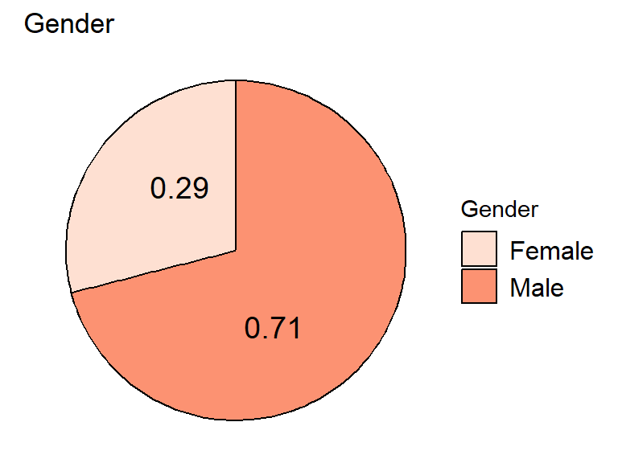

```r
pie1 =ggplot(ft, aes(x = "", y = Proportion, fill = Gender)) +
  # geom_col is a bar whose height IS the value, rather than a count
  geom_col(color = "black") +
  # print the proportion on each slice
  geom_text(aes(label = Proportion),
            position = position_stack(vjust = 0.6), size = 5) +
  # bend the stacked bar into a circle
  coord_polar(theta = "y") +
  scale_fill_brewer(palette = 'Reds') +
  # theme_void removes all axes and gridlines
  theme_void() +
  theme(legend.text = element_text(size = 12)) +
  ggtitle('Gender')

plot(pie1)
```

The bar chart uses the same frequency table:

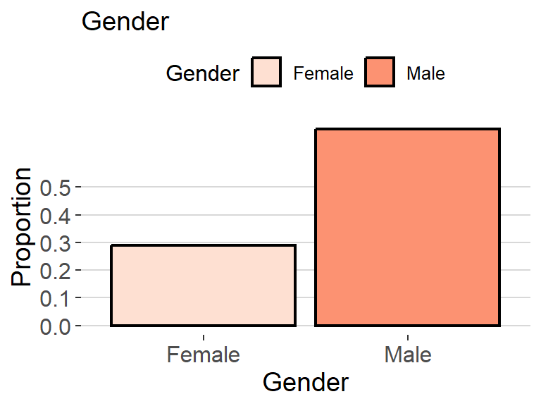

```r
BP1 =ggplot(data = ft, aes(x = Gender, y = Proportion, fill = Gender)) +
  # stat = 'identity' means "use the value I gave you", not "count the rows"
  geom_bar(stat = 'identity', color = 'black', linewidth = 0.8) +
  theme_hc() +
  # tick marks every 0.1 from 0 to 0.5
  scale_y_continuous(breaks = seq(0, 0.5, 0.1)) +
  scale_fill_brewer(palette = 'Reds') +
  theme(legend.position = 'top') +
  # theme() controls text, margins and the plot area generally
  theme(axis.text.x = element_text(size = 12),
        axis.text.y = element_text(size = 12),
        axis.title.x = element_text(size = 14),
        axis.title.y = element_text(size = 14)) +
  ggtitle("Gender")

plot(BP1)
```

# Describing a quantitative variable

Now we switch to **Studytime**, the hours per week each student reported studying.

## Stem plot

```r
# look at the raw values first - they are recorded to the nearest half hour
print(gss$Studytime)
```

```
##  [1]  7.0  2.0  4.0  3.5  4.5  3.0  3.0  8.0  5.5  5.5  5.0  7.0  9.0  4.0 10.0
## [16]  3.0  3.0  3.5  4.5  3.5  2.0  6.0  6.0  4.0  3.0  4.0 10.0  4.5  7.0  5.0
## [31]  3.0  8.0  5.0  8.0  4.5  2.0  3.0  6.0 10.0  2.0 12.0  5.0  4.0  3.0  4.0
## [46]  4.0  4.0  5.0 15.0  4.5  4.0  4.0  5.0  5.0  6.0  3.0  3.0  2.0  2.3
```

```r
# stem() picks the number of bins for you
stem(gss$Studytime)
```

```
##
##   The decimal point is at the |
##
##    2 | 0000030000000000555
##    4 | 000000000055555000000055
##    6 | 0000000
##    8 | 0000
##   10 | 000
##   12 | 0
##   14 | 0
```

By default `stem()` guesses the “prettiest” number of bins. The `scale` argument overrides that guess. Doubling it here stops the rounding to even values that you can see above:

```r
stem(gss$Studytime, scale = 2)
```

```
##
##   The decimal point is at the |
##
##    2 | 000003
##    3 | 0000000000555
##    4 | 000000000055555
##    5 | 000000055
##    6 | 0000
##    7 | 000
##    8 | 000
##    9 | 0
##   10 | 000
##   11 |
##   12 | 0
##   13 |
##   14 |
##   15 | 0
```

## Dot plot

Base R has no good dot plot, so this one is ggplot2 only.

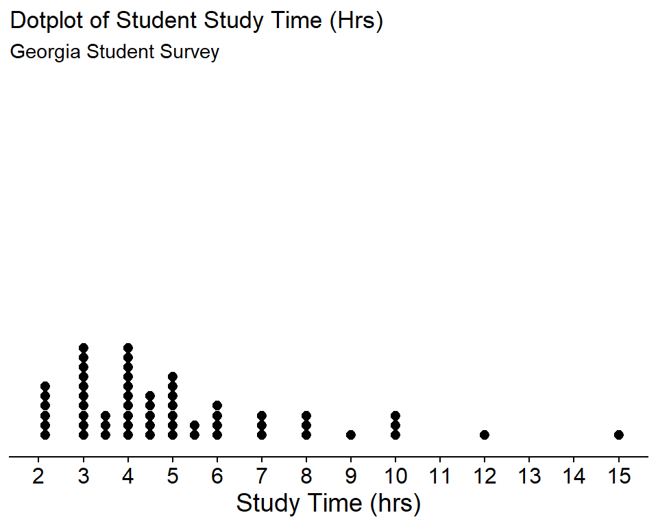

```r
ggplot(data = gss, aes(x = Studytime)) +
  geom_dotplot(dotsize = 0.5) +
  theme_classic() +
  ylab("") +
  xlab("Study Time (hrs)") +
  ggtitle('Dotplot of Student Study Time (Hrs)',
          subtitle = 'Georgia Student Survey') +
  # one tick per hour across the full range of the data
  scale_x_continuous(limits = c(min(gss$Studytime), max(gss$Studytime)),
                     breaks = seq(min(gss$Studytime), max(gss$Studytime), 1)) +
  theme(axis.text.x = element_text(size = 12),
        axis.title.x = element_text(size = 14),
        # a dot plot's y axis counts stacked dots, which is not meaningful here
        panel.background = element_blank(),
        axis.title.y = element_blank(),
        axis.text.y = element_blank(),
        axis.ticks.y = element_blank(),
        axis.line.y = element_blank())
```

## Histogram

Both packages choose a number of bins for you, but they choose differently. `hist()` uses Sturges’ method, the reasonable default we discussed in class. `geom_histogram()` just uses 30 bins and warns you to pick your own.

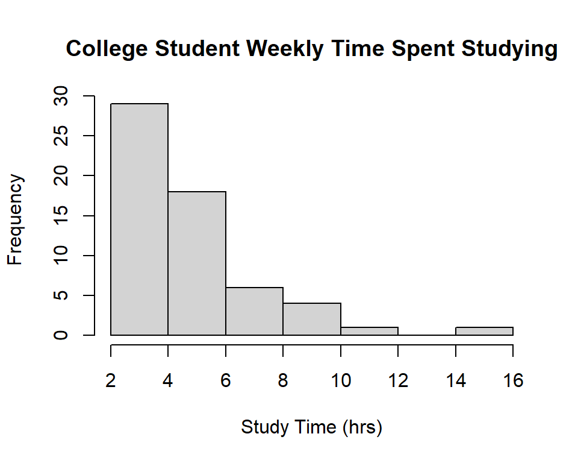

```r
hist(gss$Studytime,
     xlab = 'Study Time (hrs)',
     ylab = 'Frequency',
     main = 'College Student Weekly Time Spent Studying')
```

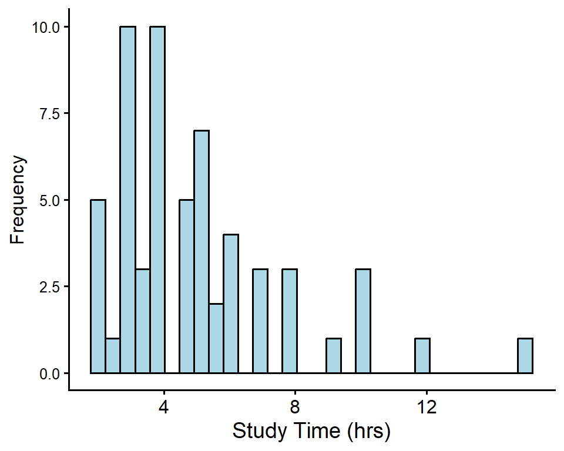

```r
ggplot(data = gss, aes(x = Studytime)) +
  geom_histogram(color = 'black', fill = 'lightblue') +
  theme_classic2() +
  ylab("Frequency") +
  xlab("Study Time (hrs)") +
  theme(axis.text.x = element_text(size = 12),
        axis.title.x = element_text(size = 14))
```

To set the bins yourself, use the `bins` or `binwidth` argument — see `?geom_histogram`. Here is the square-root rule from class:

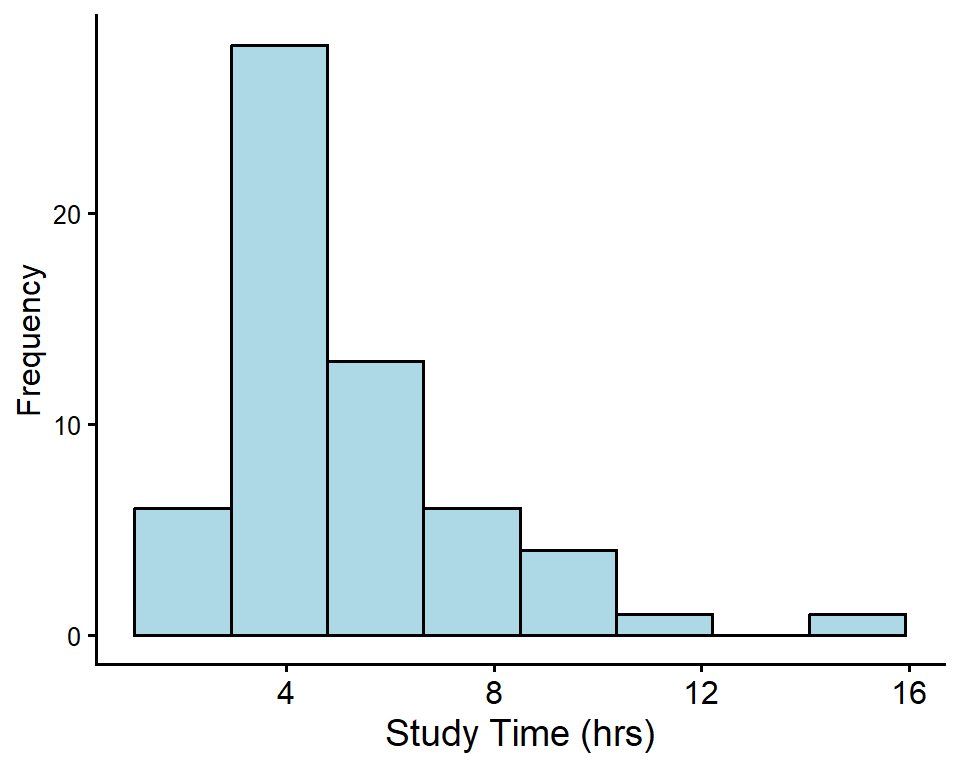

```r
n = length(gss$Studytime)
k = ceiling(sqrt(n))   # number of bins = square root of n, rounded up

ggplot(data = gss, aes(x = Studytime)) +
  geom_histogram(color = 'black', fill = 'lightblue', bins = k) +
  theme_classic2() +
  ylab("Frequency") +
  xlab("Study Time (hrs)") +
  theme(axis.text.x = element_text(size = 12),
        axis.title.x = element_text(size = 14))
```

## Boxplot

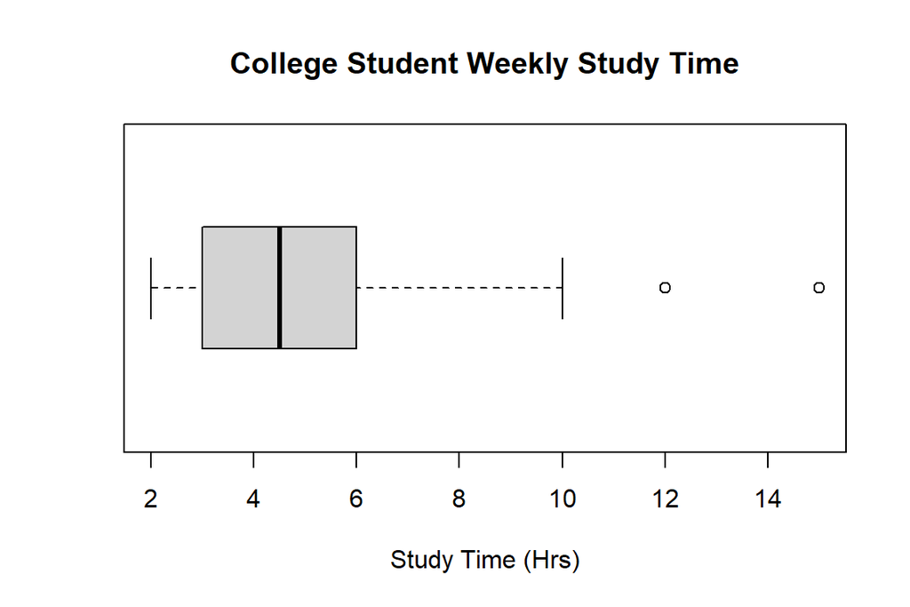

```r
boxplot(gss$Studytime,
        horizontal = T,                 # lay it on its side
        xlab = 'Study Time (Hrs)',
        main = 'College Student Weekly Study Time')
```

### Labelling the five-number summary

`text()` adds labels to any base R plot, so we can write the five-number summary directly onto the boxplot. Compute the five numbers first:

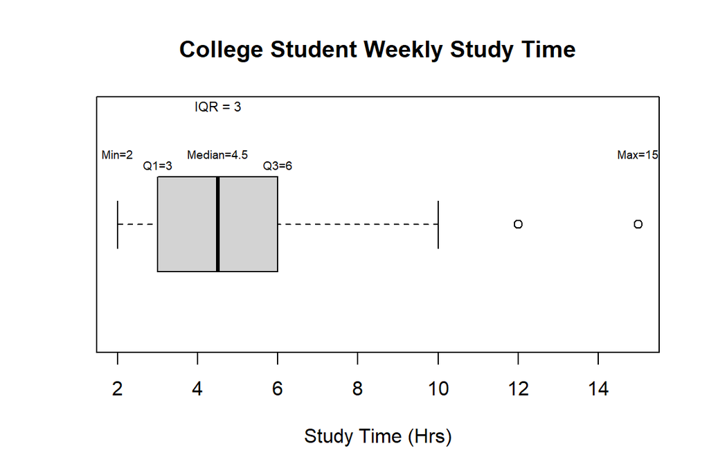

```r
minss =min(gss$Studytime)
Q1    = quantile(gss$Studytime, 0.25, type = 2)
medss = median(gss$Studytime)
Q3    = quantile(gss$Studytime, 0.75, type = 2)
maxss = max(gss$Studytime)

# the five numbers double as the x-positions of their own labels
estimates = c(minss, Q1, medss, Q3, maxss)

boxplot(gss$Studytime,
        horizontal = T,
        xlab = 'Study Time (Hrs)',
        main = 'College Student Weekly Study Time')

text(x = estimates,
     # paste() glues each name to its value: "Min=1", "Q1=5", ...
     labels = paste(c("Min", "Q1", "Median", "Q3", "Max"), estimates, sep = "="),
     # stagger the heights so neighbouring labels do not overlap
     y = c(1.3, 1.25, 1.3, 1.25, 1.3), cex = 0.6)

# the IQR goes above the box
text(x = medss, labels = paste("IQR", Q3 - Q1, sep = " = "), y = 1.5, cex = 0.7)
```

### The same thing in ggplot2

Labelling takes more work here, using `geom_label()` — one call per label, each positioned by hand.

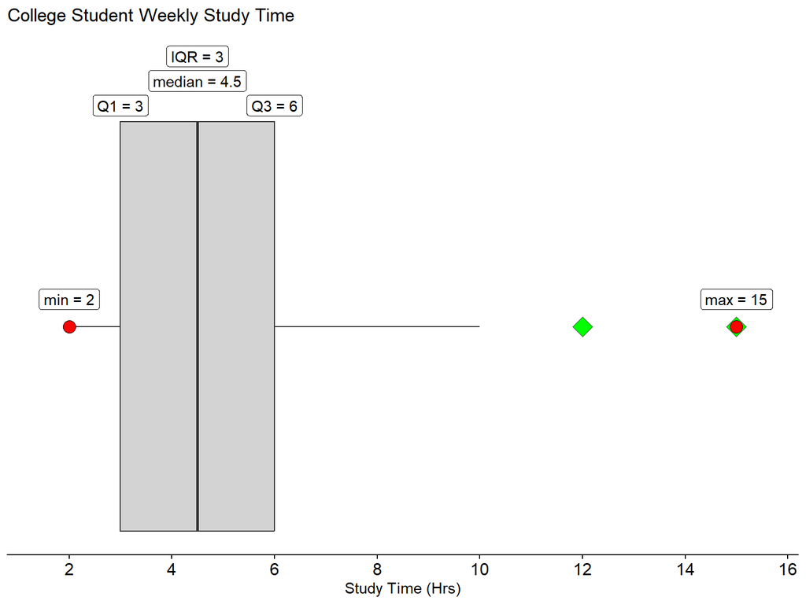

```r
ggplot() +
  geom_boxplot(aes(x = gss$Studytime),
               fill = 'lightgrey',
               outlier.shape = 23,      # diamond
               outlier.fill = 'green',
               outlier.size = 5) +
  # mark the min and max, which the box itself does not show
  geom_point(aes(x = c(minss, maxss), y = c(0, 0)),
             shape = 21, fill = 'red', size = 4) +
  # one label per summary value; y sets how high above the axis each sits
  geom_label(aes(x = minss, y = 0.05),  label = paste('min =', minss),    label.size = 0.3) +
  geom_label(aes(x = maxss, y = 0.05),  label = paste('max =', maxss),    label.size = 0.3) +
  geom_label(aes(x = medss, y = 0.45),  label = paste('median =', medss), label.size = 0.3) +
  geom_label(aes(x = Q1,    y = 0.405), label = paste('Q1 =', Q1),        label.size = 0.3) +
  geom_label(aes(x = Q3,    y = 0.405), label = paste('Q3 =', Q3),        label.size = 0.3) +
  geom_label(aes(x = medss, y = 0.495), label = paste('IQR =', Q3 - Q1),  label.size = 0.3) +
  # leave half an hour of padding either side so the labels are not clipped
  scale_x_continuous(limits = c(minss - 0.5, maxss + 0.5), n.breaks = 10) +
  theme_classic() +
  theme(axis.text.y = element_blank(),
        axis.ticks.y = element_blank(),
        axis.text.x = element_text(size = 12),
        axis.title.y = element_blank(),
        axis.line.y = element_blank()) +
  xlab('Study Time (Hrs)') +
  ggtitle('College Student Weekly Study Time')
```